# Weather Events and their Consequences

## Synopsis

This analysis uses NOAA Storm Data to answer two basic questions about severe weather events and their consequences. Specifically, this analysis answers these two questions:

1. Across the United States, which types of events (as indicated in the `EVTYPE` variable) are most harmful with respect to population health?
2. Across the United States, which types of events have the greatest economic consequences?

This document has two main sections. First, a data processing section describes how to obtain and process the data before analysis. A results section follows that analyzes the data to answer the two questions.

## Data Processing

The first step is to download, extract, and read the data file.

```r
download.file("https://d396qusza40orc.cloudfront.net/repdata%2Fdata%2FStormData.csv.bz2", "stormdata.csv.bz2")

stormdata <- read.csv("stormdata.csv.bz2")
```

Let’s look at the dimensions and structure of the data to get an understanding of what’s going on.

```r
dim(stormdata)
```

```
## [1] 902297     37
```

```r
str(stormdata)
```

```
## 'data.frame':    902297 obs. of  37 variables:
##  $ STATE__   : num  1 1 1 1 1 1 1 1 1 1 ...
##  $ BGN_DATE  : Factor w/ 16335 levels "10/10/1954 0:00:00",..: 6523 6523 4213 11116 1426 1426 1462 2873 3980 3980 ...
##  $ BGN_TIME  : Factor w/ 3608 levels "000","0000","00:00:00 AM",..: 212 257 2645 1563 2524 3126 122 1563 3126 3126 ...
##  $ TIME_ZONE : Factor w/ 22 levels "ADT","AKS","AST",..: 7 7 7 7 7 7 7 7 7 7 ...
##  $ COUNTY    : num  97 3 57 89 43 77 9 123 125 57 ...
##  $ COUNTYNAME: Factor w/ 29601 levels "","5NM E OF MACKINAC BRIDGE TO PRESQUE ISLE LT MI",..: 13513 1873 4598 10592 4372 10094 1973 23873 24418 4598 ...
##  $ STATE     : Factor w/ 72 levels "AK","AL","AM",..: 2 2 2 2 2 2 2 2 2 2 ...
##  $ EVTYPE    : Factor w/ 985 levels "?","ABNORMALLY DRY",..: 830 830 830 830 830 830 830 830 830 830 ...
##  $ BGN_RANGE : num  0 0 0 0 0 0 0 0 0 0 ...
##  $ BGN_AZI   : Factor w/ 35 levels "","E","Eas","EE",..: 1 1 1 1 1 1 1 1 1 1 ...
##  $ BGN_LOCATI: Factor w/ 54429 levels "","?","(01R)AFB GNRY RNG AL",..: 1 1 1 1 1 1 1 1 1 1 ...
##  $ END_DATE  : Factor w/ 6663 levels "","10/10/1993 0:00:00",..: 1 1 1 1 1 1 1 1 1 1 ...
##  $ END_TIME  : Factor w/ 3647 levels "","?","0000",..: 1 1 1 1 1 1 1 1 1 1 ...
##  $ COUNTY_END: num  0 0 0 0 0 0 0 0 0 0 ...
```

[output cut: 23 more lines]

Based on this, it looks like we will use `EVTYPE` for the type of event in each question. For the first question, we want to look at `FATALITIES` and `INJURIES`. For the second question, we want to look at `PROPDMG` and `CROPDMG`.

For property and crop damage to work correctly in the analysis of the second question, we need to multiply `PROPDMG` and `CROPDMG` by an appropriate amount based on the related `EXP` field. We will the only valide `EXP` field values are “B”, “b”, “M”, “m”, “K”, and “k” based off the [Storm Data Documentation](https://d396qusza40orc.cloudfront.net/repdata%2Fpeer2_doc%2Fpd01016005curr.pdf) (see page 12).

To do this, we’ll use the `dplyr` package to mutate a couple additional columns on to the data frame. Before we can do that, let’s make a couple vecotrs to align with `CROPDMGEXP` and ``PROPDMGEXP` converting the letters to numbers. Then, we can mutate the data frame.

We’ll use a function for the tranformation from letters to number `EXP` variables:

```r
convexp <- function(expvect) {
  i <- 1
  goodexps <- vector(mode = "numeric", length = length(expvect))
  for (value in expvect) {
    if (value == "K" || value == "k") { value <- 1000 }
    else if (value == "M" || value == "m") { value <- 1000000 }
    else if (value == "B" || value == "b") { value <- 1000000000 }
    else value <- 0

    goodexps[i] <- value
    i <- i + 1
  }

  return(goodexps)

}
```

Here is the transformation and mutation.

```r
crpexp <- stormdata$CROPDMGEXP

prpexp <- stormdata$PROPDMGEXP

crpexp <- convexp(crpexp)

prpexp <- convexp(prpexp)

library(dplyr)

stormdataready <- mutate(stormdata, TOTPRPDMG = prpexp * PROPDMG, TOTCRPDMG = crpexp * CROPDMG, TOTDMG = prpexp * PROPDMG + crpexp * CROPDMG)
```

We need to do something similar for fatalities and injuries. For the purposes of this analysis, we will assume fatalities and injuries carry equal weight.

```r
stormdataready <- mutate(stormdataready, TOTHLT = FATALITIES + INJURIES)
```

One more step before looking at results. We need to aggregate the data down to event type.

```r
cleanstorm <- aggregate(cbind(TOTHLT, TOTDMG) ~ EVTYPE, stormdataready, FUN = sum)
```

## Results

Now, it’s time to address each question.

### Event Type and Population Health

1. Across the United States, which types of events (as indicated in the `EVTYPE` variable) are most harmful with respect to population health?

Because there are 985 event types, let’s find the 15 event types with the most fatalities and injuries.

```r
topevs <- cleanstorm[head(order(cleanstorm$TOTHLT, decreasing = TRUE), n = 15L), c("EVTYPE", "TOTHLT")]
topevs
```

```
##                EVTYPE TOTHLT
## 830           TORNADO  96979
## 123    EXCESSIVE HEAT   8428
## 854         TSTM WIND   7461
## 164             FLOOD   7259
## 452         LIGHTNING   6046
## 269              HEAT   3037
## 147       FLASH FLOOD   2755
## 424         ICE STORM   2064
## 759 THUNDERSTORM WIND   1621
## 972      WINTER STORM   1527
## 354         HIGH WIND   1385
## 238              HAIL   1376
## 406 HURRICANE/TYPHOON   1339
## 304        HEAVY SNOW   1148
## 953          WILDFIRE    986
```

Let’s plot the top 5 event types using ggplot2.

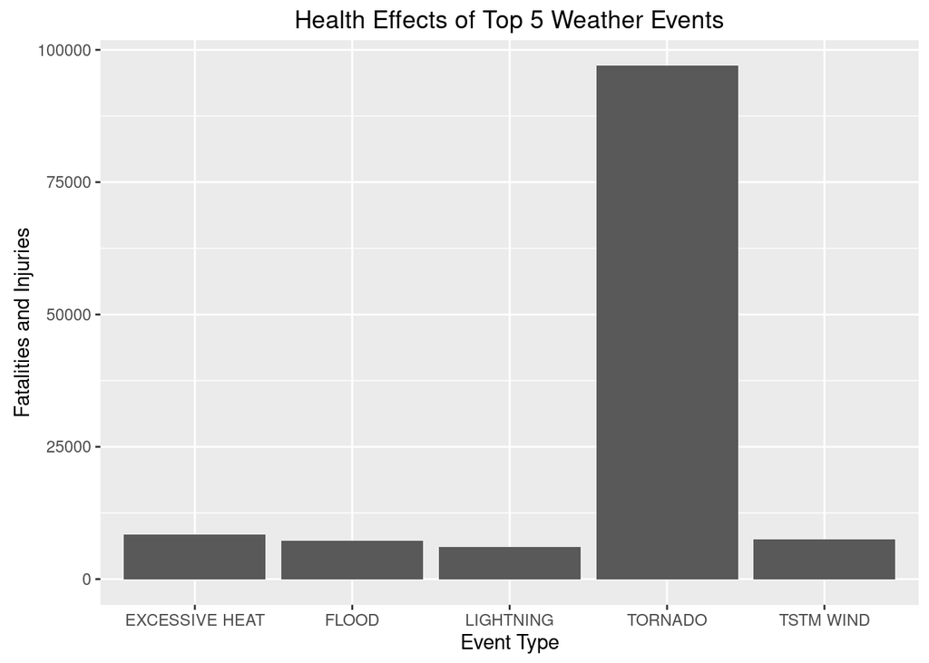

```r
library(ggplot2)

ggplot(topevs[1:5, ], aes(EVTYPE, TOTHLT)) + geom_bar(stat = "identity") + ylab("Fatalities and Injuries") + xlab("Event Type") + ggtitle("Health Effects of Top 5 Weather Events")
```

### Event Type and Economic Impact

2. Across the United States, which types of events have the greatest economic consequences?

Similar to the first question, let’s concentrate on the 15 event types with the highest property and crop costs.

```r
topcostevs <- cleanstorm[head(order(cleanstorm$TOTDMG, decreasing = TRUE), n = 15L), c("EVTYPE", "TOTDMG")]
topcostevs
```

```
##                EVTYPE       TOTDMG
## 164             FLOOD 150319678250
## 406 HURRICANE/TYPHOON  71913712800
## 830           TORNADO  57352113590
## 666       STORM SURGE  43323541000
## 238              HAIL  18758221170
## 147       FLASH FLOOD  17562128610
## 88            DROUGHT  15018672000
## 397         HURRICANE  14610229010
## 586       RIVER FLOOD  10148404500
## 424         ICE STORM   8967041310
## 844    TROPICAL STORM   8382236550
## 972      WINTER STORM   6715441250
## 354         HIGH WIND   5908617560
## 953          WILDFIRE   5060586800
## 854         TSTM WIND   5038935790
```

Let’s plot the top 5 event types.

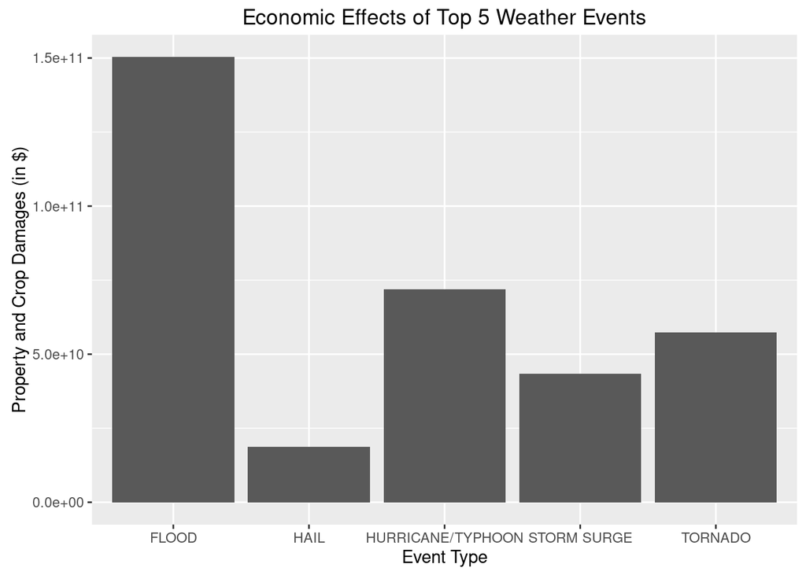

```r
ggplot(topcostevs[1:5, ], aes(EVTYPE, TOTDMG)) + geom_bar(stat = "identity") + ylab("Property and Crop Damages (in $)") + xlab("Event Type") + ggtitle("Economic Effects of Top 5 Weather Events")
```

### Caveats

A couple parting caveats:

1. The data are messy and the data processing step only partially cleaned the data. It did not address the fact that many event types are repeated with different spellings (e.g. “Wintry mix” and “WINTERY MIX”). This reduces the total count for some events in both questions.
2. Data processing did not account for entries in the `EXP` field that did not match the guide. For example, “H” and “h” probably means “hundreds”, but this is not called out in the guide. Therefore those values were ignored (assumed to be zero).